# Regressão Romântica

Lorena Pereira

9 de julho de 2019

# Atividade

Utilizar regressão logística em um conjunto de variáveis para entender que fatores nos dados têm efeito relevante na chance do casal ter um match? Descrevendo se os efeitos são positivos ou negativos e sua magnitude.

# “The context, give me the context!”

Encontros relâmpagos ou speed dating são eventos onde várias pessoas solteiras conversam por 4 minutos e por fim decidem se saíriam novamente com as pessoas que conversaram ou não. Um Tinder presencial… A partir disso

> Temos dados descrevendo 5000 encontros relâmpagos de 4 minutos envolvendo 310 jovens americanos. Os dados originais foram coletados por professores da Columbia Business School [no experimento descrito aqui](http://faculty.chicagobooth.edu/emir.kamenica/documents/genderDifferences.pdf).

E nesses dados temos informações como:

- iid : id do participante p1 no encontro
- gender : sexo do p1, 0 = mulher
- order : dos vários encontros realizados em uma noite, esse foi o n-ésimo, segundo essa variável
- pid : id do participante p2
- int_corr : correlação entre os interesses de p1 e p2
- samerace : p1 e p2 são da mesma raça?
- age_o : idade de p2
- age : idade de p1
- field : campo de estudo de p1
- race : raça de p1. O código é Black/African American=1; European/Caucasian-American=2; Latino/Hispanic American=3; Asian/Pacific Islander/Asian-American=4; Native American=5; Other=6
- from : de onde p1 é
- career : que carreira p1 quer seguir
- sports, tvsports, exercise, dining, museums, art, hiking, gaming, clubbing, reading, tv, theater, movies, concerts, music, shopping, yoga : De 1 a 10, quão interessado p1 é em cada uma dessas atividades.
- attr : quão atraente p1 achou p2
- sinc : quão sincero p1 achou p2
- intel : quão inteligente p1 achou p2
- fun : quão divertido p1 achou p2
- amb : quão ambicioso p1 achou p2
- shar : quanto p1 achou que compartilha interesses e hobbies com p2
- like : no geral, quanto p1 gostou de p2?
- prob : que probabiliade p1 acha que p2 tem de querer se encontrar novamente com p- (escala 1-10)
- attr3_s : quanto p1 acha que é atraente
- sinc3_s : quanto p1 acha que é sincero
- intel3_s : quanto p1 acha que é inteligente
- fun3_s : quanto p1 acha que é divertido
- amb3_s : quanto p1 acha que é ambicioso
- dec: se houve match entre os dois participantes do encontro

Mãos a obra!

# Análise

## Descritivo dos dados

```r
dados <- read_csv("../dados/speed-dating2.csv") %>%
  mutate(dec = as.factor(dec),
         gender = as.factor(gender),
         diff_age = abs(age_o - age))
skim(dados)
```

```
## Skim summary statistics
##  n obs: 4918
##  n variables: 45
##
## ── Variable type:character ────────────────────────────────────────────────────────────────────────────────────────────────────
##  variable missing complete    n min max empty n_unique
##    amb3_s    2874     2044 4918   1   2     0        8
##   attr3_s    2874     2044 4918   4   5     0        9
##    career      46     4872 4918   2  77     0      218
##     field      20     4898 4918   3  51     0      148
##      from      36     4882 4918   2  58     0      172
##    fun3_s    2874     2044 4918   1   2     0        8
##  intel3_s    2874     2044 4918   4   5     0        7
##   sinc3_s    2874     2044 4918   4   5     0        8
##
## ── Variable type:factor ───────────────────────────────────────────────────────────────────────────────────────────────────────
##  variable missing complete    n n_unique                 top_counts
##       dec       0     4918 4918        2 no: 2873, yes: 2045, NA: 0
##    gender       0     4918 4918        2    1: 2464, 0: 2454, NA: 0
##  ordered
##    FALSE
##    FALSE
##
## ── Variable type:integer ──────────────────────────────────────────────────────────────────────────────────────────────────────
##  variable missing complete    n   mean     sd p0 p25 p50 p75 p100     hist
##       age      52     4866 4918  25.78   3.35 18  23  25  28   39 ▁▇▆▇▃▁▁▁
##     age_o      61     4857 4918  25.79   3.35 18  23  25  28   39 ▁▇▆▇▃▁▁▁
##       art      36     4882 4918   6.59   2.29  0   5   7   8   10 ▁▁▃▆▃▆▇▇
##  clubbing      36     4882 4918   5.73   2.45  0   4   6   8   10 ▃▂▃▇▅▆▆▅
##  concerts      36     4882 4918   6.82   2.1   0   6   7   8   10 ▁▁▂▅▆▆▇▇
##  diff_age     112     4806 4918   3.43   2.76  0   1   3   5   17 ▇▅▂▂▁▁▁▁
##    dining      36     4882 4918   7.69   1.79  1   7   8   9   10 ▁▁▁▂▂▅▅▇
##  exercise      36     4882 4918   6.12   2.33  1   5   6   8   10 ▅▃▃▇▇▇▇▇
##    gaming      36     4882 4918   4.02   2.67  0   2   4   6   14 ▆▇▆▆▂▁▁▁
##    hiking      36     4882 4918   5.77   2.56  0   4   6   8   10 ▂▃▅▇▅▅▆▆
##       iid       0     4918 4918 274.67 183.91  1  88 273 431  552 ▇▇▁▆▃▆▃▇
##    movies      36     4882 4918   7.98   1.67  0   7   8   9   10 ▁▁▁▁▁▃▅▇
##   museums      36     4882 4918   6.88   2.08  0   6   7   8   10 ▁▁▂▅▃▇▇▇
##     music      36     4882 4918   7.78   1.84  1   7   8   9   10 ▁▁▁▂▂▃▅▇
##     order       0     4918 4918   9.26   5.67  1   4   9  14   22 ▇▇▅▇▅▃▅▂
```

[output cut: 19 more lines]

```
##  match_es     460     4458 4918 3.17 2.36  0     2    3    4    10
##      prob     156     4762 4918 5.02 2.17  0     4    5    7    10
##      shar     643     4275 4918 5.32 2.16  0     4    5    7    10
##      sinc     161     4757 4918 7.05 1.81  0     6    7    8    10
##      hist
##  ▁▁▁▇▇▇▇▆
##  ▁▁▂▇▆▆▅▃
##  ▁▁▂▇▇▇▆▃
##  ▁▂▅▆▇▇▅▁
##  ▁▁▁▃▅▇▇▆
##  ▁▁▂▇▇▇▅▂
##  ▇▇▆▇▁▁▁▂
##  ▂▂▂▇▃▃▂▁
##  ▁▂▂▇▅▃▂▂
##  ▁▁▁▅▆▇▇▆
```

A fim de facilitar um possível entendimento dos fatores de maior sucesso nos matchs vamos diminuir o escopo para os seguintes campos:

- **shar**: Será que os opostos se atraem mesmo?
- **diff_age** (diferença de idades entre p1 e p2, calculada a partir dos campos existente): E como a diferença de idade pode intervir nisso?
- **intel**: Inteligência conta?
- **fun**: Ser divertido com certeza… Né? Bom, vamos ver!

Como já sabemos quais dados vamos investigar, vamos tentar visualizar uma correlação entre eles. Mas primeiro vamos retirar os resgistros com valores nulos.

```r
dados <- dados %>%
  select(shar, diff_age, intel, fun, dec)

dados <- na.omit(dados)

skim(dados)
```

```
## Skim summary statistics
##  n obs: 4157
##  n variables: 5
##
## ── Variable type:factor ───────────────────────────────────────────────────────────────────────────────────────────────────────
##  variable missing complete    n n_unique                 top_counts
##       dec       0     4157 4157        2 no: 2380, yes: 1777, NA: 0
##  ordered
##    FALSE
##
## ── Variable type:integer ──────────────────────────────────────────────────────────────────────────────────────────────────────
##  variable missing complete    n mean   sd p0 p25 p50 p75 p100     hist
##  diff_age       0     4157 4157 3.37 2.71  0   1   3   5   17 ▇▅▂▂▁▁▁▁
##
## ── Variable type:numeric ──────────────────────────────────────────────────────────────────────────────────────────────────────
##  variable missing complete    n mean   sd p0 p25 p50 p75 p100     hist
##       fun       0     4157 4157 6.28 1.99  0   5   6   8   10 ▁▁▂▇▇▇▆▅
##     intel       0     4157 4157 7.26 1.59  0   6   7   8   10 ▁▁▁▃▅▇▇▆
##      shar       0     4157 4157 5.32 2.16  0   4   5   7   10 ▁▂▂▇▅▃▂▂
```

Visualizando correlação

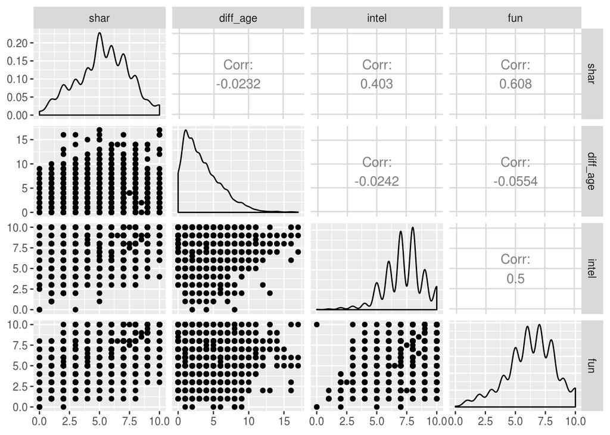

```r
ggpairs(dados %>% select(shar, diff_age, intel, fun))
```

Gerando o modelo:

```r
match_model = glm(dec ~ shar + diff_age + intel + fun,
                        data = dados,
                        family = "binomial")

tidy(match_model, conf.int = TRUE, exponentiate = TRUE, conf.level = .95)
```

```
## # A tibble: 5 x 7
##   term        estimate std.error statistic  p.value conf.low conf.high
##   <chr>          <dbl>     <dbl>     <dbl>    <dbl>    <dbl>     <dbl>
## 1 (Intercept)   0.0249    0.205     -18.1  6.05e-73   0.0166    0.0370
## 2 shar          1.38      0.0218     14.8  1.30e-49   1.32      1.44
## 3 diff_age      0.979     0.0132     -1.63 1.04e- 1   0.954     1.00
## 4 intel         0.907     0.0287     -3.39 6.93e- 4   0.857     0.960
## 5 fun           1.45      0.0265     14.1  2.86e-45   1.38      1.53
```

```r
pR2(match_model)
```

```
##           llh       llhNull            G2      McFadden          r2ML
## -2339.1072012 -2837.5236072   996.8328120     0.1756519     0.2132118
##          r2CU
##     0.2863191
```

Analisando o modelo considerando o pseudo R2 de McFadden vemos que o nosso modelo explica 17% dos nossos dados. Ou seja no nosso modelo ser divertido é o que mais importa, já ser inteligente nem tanto, mas ainda não temos um poder de explicação tão grande entre os matchs.